# Mental Health Survey

## Support Vector Machine

In this section we’ll start training a model using the linear kernel, with all the available variables and use that as a benchmark for any other SVM models we may train. The idea is to minimize test error and maximize interpretability. In the real world, being able to interpret the model will help one explain what makes the model work, but in some cases understanding how the model works takes a back seat to pure predictive power. This model won’t be used to make any life altering predictions, so we’ll discuss the results along the way.

We’ll create new training and test sets in order to preserve as many rows as possible. The raw data will have the `initial` and `psych_meds` fields omitted, and the rest of the observations with any missing values will be omitted. We’ll also be setting the tune length to 8, which is an arbitrary choice. We would like to set the number high enough to tune through a number of variations, but not too high where it would take too much processing power and time to train one model.

All models below will be trained using 10 fold cross validation and will have all variables centered and scaled before training. Using a 75/25 split leaves us with 106 training and 35 test observations. Note that the bag impute method fills in decimals where the variable may refer to a question with discrete answers. This may not be ideal, but is acceptable because each of the questions follow a similar scale of none/low to more/high in increasing order.

Finally, the last thing to note is that the dataset we’re working with has about 30% of observations flagged for suicide.

```r
df5 <- df_raw2 %>%
  select(-initial, -psych_meds) %>%
  na.omit

set.seed(101)
trainIndex <- createDataPartition(df5$suicide,
                                  p = 0.75,
                                  list = F)

train <- df5[trainIndex,]
test <- df5[-trainIndex,]

ctrl <- trainControl(method = 'cv', number = 10)
tune_length <- 8
```

### Pairs Plot

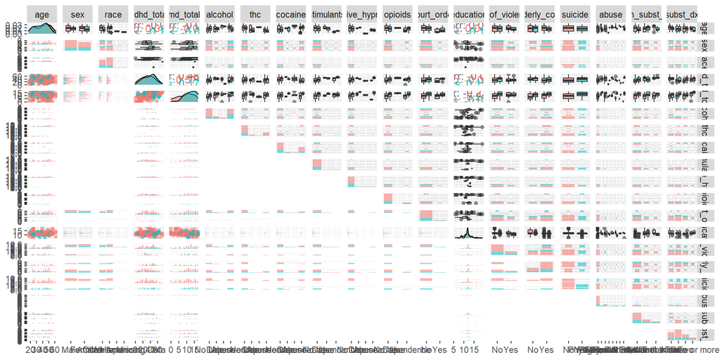

```r
library(GGally)

# excluding individual questions for pairs plot
df6 <- df5 %>%
  select(age, sex, race, adhd_total, md_total) %>%
  bind_cols(df5[,39:52])

ggpairs(df6,
        mapping=ggplot2::aes(colour = suicide, alpha = 0.3))
```

The first step we took is to generate a pairs plot to look for any obvious separations. The idea is to visually identify any possible variable combinations where we could clearly separate people who had attempted suicide or not. Unfortunately this method is limited to two dimensions as it’s difficult to visualize higher dimensions and looking at the chart above, there aren’t any obvious separations we can make.

### All Variables

#### SVM Linear, All Variables

```r
svm_linear <- train(suicide ~ .,
                    data = train,
                    method = 'svmLinear',
                    preProc = c('center', 'scale'),
                    tuneLength = tune_length,
                    trControl = ctrl
                    )

test$svm_linear <- predict(svm_linear, test)

svm_linear
```

```
## Support Vector Machines with Linear Kernel
##
## 106 samples
##  51 predictor
##   2 classes: 'No', 'Yes'
##
## Pre-processing: centered (132), scaled (132)
## Resampling: Cross-Validated (10 fold)
## Summary of sample sizes: 96, 95, 96, 96, 94, 95, ...
## Resampling results:
##
##   Accuracy   Kappa
##   0.6210606  0.09399862
##
## Tuning parameter 'C' was held constant at a value of 1
```

#### SVM Poly, All Variables

Next, let’s train another SVM model with the same parameters as the linear model, only changing the method to use a polynomial to see if we can reach higher levels of accuracy. By keeping all the conditions the same except for the method, we can see which method fits better and is a more appropriate choice.

```r
svm_poly <- train(suicide ~ .,
                  data = train,
                  method = 'svmPoly',
                  preProc = c('center', 'scale'),
                  tuneLength = tune_length,
                  trControl = ctrl
                  )

test$svm_poly <- predict(svm_poly, test)

x <- svm_poly$bestTune %>%
  row.names()

svm_poly$results[x,]
```

```
##     degree scale   C Accuracy     Kappa AccuracySD   KappaSD
## 138      3  0.01 0.5 0.700303 0.1350472  0.1387149 0.3868994
```

Looking at the results of the best model above, the tuned polynomial method produced a higher level of accuracy, around 70%. Although the results were slightly better than the linear model, we can’t make the case that this model is better before looking at the relative test errors.

#### SVM Radial, All Variables

The next method we’ll try is the radial method. This will allow for a circular boundary rather than a straight or curved line.

```r
svm_radial <- train(suicide ~ .,
                    data = train,
                    method = 'svmRadial',
                    preProc = c('center', 'scale'),
                    tuneLength = tune_length,
                    trControl = ctrl
                    )

test$svm_radial <- predict(svm_radial, test)

x <- svm_radial$bestTune %>%
  row.names()

svm_radial$results[x,]
```

```
##         sigma    C Accuracy Kappa AccuracySD KappaSD
## 1 0.004455678 0.25 0.689697     0 0.02572091       0
```

If one of the two methods performed significantly better than the other, we could move forward and stick with that method. The next step we’ll take is to reconsider the variables included and then run the models again. If we were short on time and resources, it would make sense to continue with just the best performing polynomial method, but since we’re experimenting and exploring here, we’ll run all three methods again and see what we get.

Also note while writing up this report, each model was run multiple times and the results were not consistent for each model. It’s possible that the accuracy levels and results shown may vary when producing the final report.

### Limited Variables

When building models, collinearity and noise can present hurdles to creating a production quality model. Maybe one day we’ll have computers that are fast enough to train every single combination of variables and pick the best one, but for now we’re going to consider all of the variables and decide which ones to move forward with.

It would make sense for us to try excluding all of the individual ADHD and mood disorder questions, since the totals for each respective state of mind allows us to get a higher level view of these variables. Below, we’ll create a copy of the training dataset excluding the individual questions, the retrain the three types of SVM models and evaluate the training results.

Finally, we’ll compare the test results for each of the 6 models.

#### Training DataFrame v2

```r
train2 <- train %>%
  select(age, sex, race, adhd_total, md_total) %>%
  bind_cols(train[,39:52])
```

We created another dataframe object here to make things easier downstream. Instead of specifically selecting all of the variables, this object, `train2`, is a copy of `train1` without the individual question variables.

#### SVM Linear v2

```r
svm_linear2 <- train(suicide ~ .,
                     data = train2,
                     method = 'svmLinear',
                     preProc = c('center', 'scale'),
                     tuneLength = tune_length,
                     trControl = ctrl
                     )

test$svm_linear2 <- predict(svm_linear2, test)

svm_linear2
```

```
## Support Vector Machines with Linear Kernel
##
## 106 samples
##  18 predictor
##   2 classes: 'No', 'Yes'
##
## Pre-processing: centered (43), scaled (43)
## Resampling: Cross-Validated (10 fold)
## Summary of sample sizes: 96, 94, 96, 95, 96, 94, ...
## Resampling results:
##
##   Accuracy   Kappa
##   0.6689394  0.1842511
##
## Tuning parameter 'C' was held constant at a value of 1
```

#### SVM Polynomial v2

```r
svm_poly2 <- train(suicide ~ .,
                   data = train2,
                   method = 'svmPoly',
                   preProc = c('center', 'scale'),
                   tuneLength = tune_length,
                   trControl = ctrl
                   )

test$svm_poly2 <- predict(svm_poly2, test)

x <- svm_poly2$bestTune %>%
  row.names()

svm_poly2$results[x,]
```

```
##   degree scale  C  Accuracy    Kappa AccuracySD   KappaSD
## 8      1 0.001 32 0.7093939 0.213993 0.08807536 0.2971142
```

The 2nd polynomial SVM model has the simliar levels of accuracy to all earlier models. This model is comparable to the 1st polynomial SVM, giving additional evidence that the omission of the individual ADHD and mood disorder questions is mainly adding value by creating relatively easier to interpret models.

#### SVM Radial v2

```r
svm_radial2 <- train(suicide ~ .,
                     data = train2,
                     method = 'svmRadial',
                     preProc = c('center', 'scale'),
                     tuneLength = tune_length,
                     trControl = ctrl
                     )

test$svm_radial2 <- predict(svm_radial2, test)

x <- svm_radial2$bestTune %>%
  row.names()

svm_radial$results[x,]
```

```
##         sigma    C Accuracy Kappa AccuracySD KappaSD
## 1 0.004455678 0.25 0.689697     0 0.02572091       0
```

Again, the second radial model using fewer variables has no obvious advantage in predictive training accuracy. We will need to check the test error of every model to decide which one would be best to use for future predictions.

### SVM Test Evaluation

```r
data.frame(rbind(
  postResample(test$svm_linear, test$suicide),
  postResample(test$svm_poly, test$suicide),
  postResample(test$svm_radial, test$suicide),
  postResample(test$svm_linear2, test$suicide),
  postResample(test$svm_poly2, test$suicide),
  postResample(test$svm_radial2, test$suicide)
),
row.names = c('SVM linear, all variables',
              'SVM poly, all variables',
              'SVM radial, all variables',
              'SVM linear, limited',
              'SVM poly, limited',
              'SVM radial, limited'
              )
)
```

```
##                            Accuracy     Kappa
## SVM linear, all variables 0.6285714 0.2649435
## SVM poly, all variables   0.7142857 0.3371212
## SVM radial, all variables 0.6857143 0.0000000
## SVM linear, limited       0.6000000 0.1551724
## SVM poly, limited         0.7142857 0.3027888
## SVM radial, limited       0.6857143 0.0000000
```

```r
### This section was inspired by the pairs plot... it was difficult to read that plot, so the 2 dimensional scatter plots were generated individually

var_count <- ncol(train2)

# pair plot, one at a time
c <- 1
for (i in 1:var_count) {
  for (j in (i+1):var_count) {
    if (i == 16 | j == 16) {

    } else {
      print(str_c(c, ": ", i, ', ', j))

      temp_df <- train2[,c(i,j,16)]
      temp_names <- names(temp_df)
      names(temp_df) <- c('x', 'y', 'suicide')

      print(temp_names[1:2])

      p <- ggplot(temp_df, aes(x = x, y = y, color = suicide)) +
        geom_jitter(alpha = 0.7) +
        labs(x = temp_names[1],
             y = temp_names[2])

      print(p)

      readline(prompt="Press [enter] to continue")
      c <- c + 1
    }
  }
}



# pair plot, one variable vs the others as facets
for (i in 1:var_count) {
  if (i != 16) {

    temp_df <- train2[i:var_count]

    if (i > 16) {
      temp_df <- temp_df %>%
        bind_cols(train2[16])
    }

    temp_ncol <- ncol(temp_df)

    fixed_var <- names(temp_df)[1]
    names(temp_df)[1] <- 'x'

    p <- temp_df %>%
      gather(var, val, -x, -suicide) %>%
      ggplot(aes(x = x, y = val, color = suicide)) +
      geom_jitter(alpha = 0.7) +
      facet_wrap(~var, scales = 'free') +
      labs(x = fixed_var)

    print(p)
    readline(prompt="Press [enter] to continue")

  }
}
```

## References

1. [ADHD symptoms and suicide attempts in adults with mood disorders: An observational naturalistic study](https://www.sciencedirect.com/science/article/pii/S2666915321001505)
2. [The Adult ADHD Self-Reporting Scale Symptoms Checklist](https://add.org/wp-content/uploads/2015/03/adhd-questionnaire-ASRS111.pdf)
3. [Mood Disorder Questionnaire](https://www.ncbi.nlm.nih.gov/pmc/articles/PMC314375/)